# Communicating Data Science Results

Eric Farng

November 26, 2015

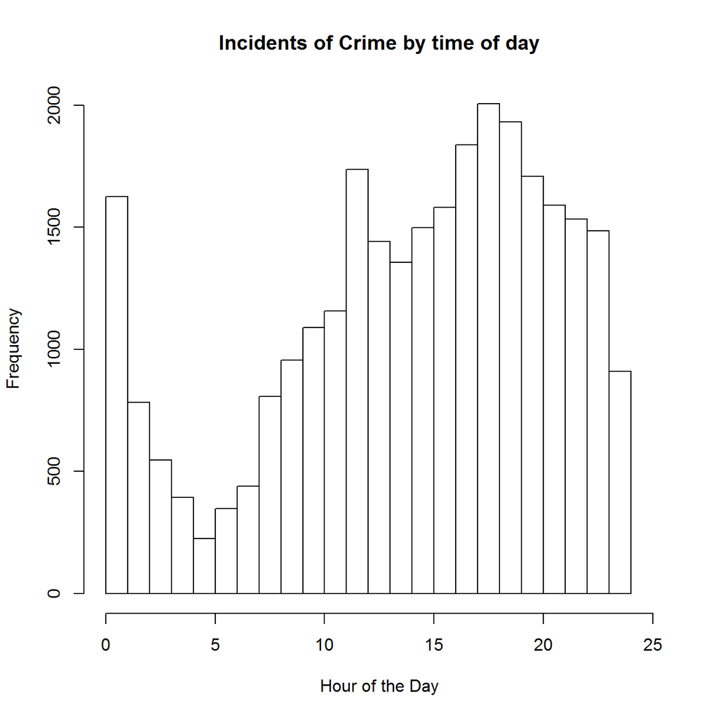

Next, I looked at the trend of different categories of crimes across the time of day. The Time of day was bucketed into 6 4-hour time periods.

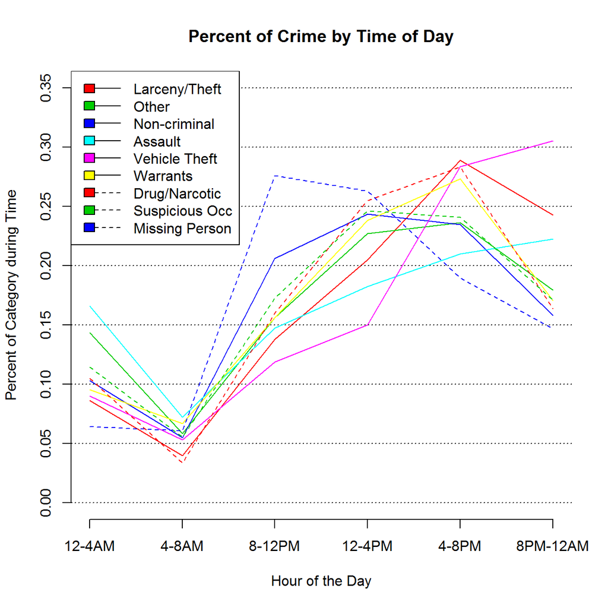

I choose the top 9 most common crime categories. The most common is on the top of the legend and the least common is on the bottom. Since each category has a different amount of total indicents, each curve was normalized to a probability so each value is the percent of crimes during those hours. So 31% of Vehicle Theft occurred between 8PM and 12AM

We can see a general trend of crime mostly occuring later in the evening when it is dark. And the least crime happens from 4am-8am. Even criminals need to sleep.

We see that Assults are most common in the early hours (12-4AM) and they were third most common from 8PM-12AM.

Missing Persons are most common from 8am-12PM which would be when they are mostly commonly reported.

Vehicle theft and Larceny theft occur late in the evening. Non-criminal crime happens mostly during the day.

Below are the number of incidents for each time. Larceny/Theft have the most incidents throughout the day. We can see that Missing persons have a higher portion of the incidents from 8AM to Noon, but still has fewer incidents than Larceny/Theft

### Key Findings

We find that the fewest crimes happen between 4AM and 5AM. The most occur beteen 5PM and 6PM. The Top 9 crimes generally follow this trend. Larceny/Theft peaks between 4PM and 8PM. Vehicle theft peaks at 8PM-midnight. This is as expected, when the crimes are most likely to happen. However, missing persons peak between 8AM and Noon. This is unlikely the time when the person went missing. Instead, this is the time when the person was reported missing.

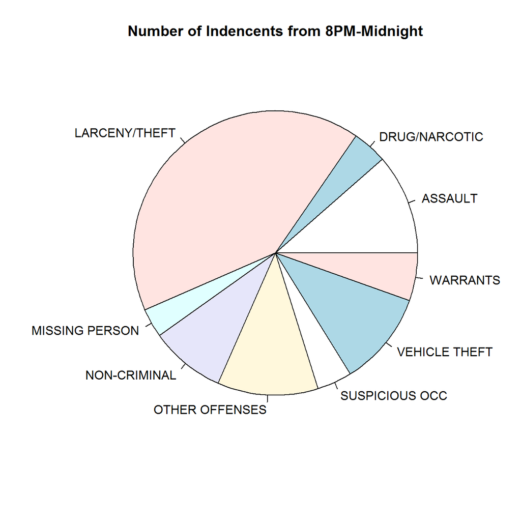

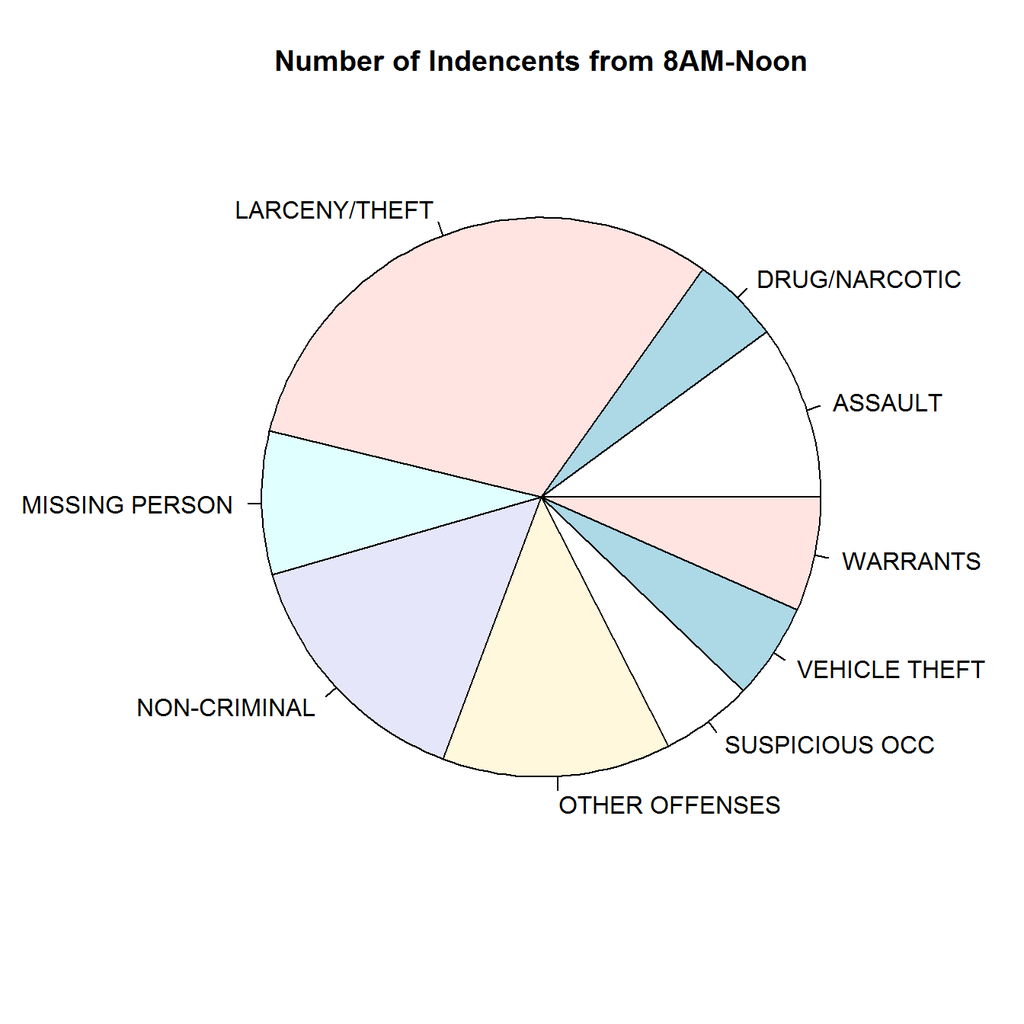

## Tools

This project was created using R Markdown. The Rmd file is included in this github repository

https://github.com/ericfarng/data_science_at_scale/blob/master/Communicating%20Data%20Science%20Results.Rmd